# Start

# Model:

## Regressions Not Normalized

### Methodology

In this section, the algorithms will be run without being normalized and further ahead they will be Normalized

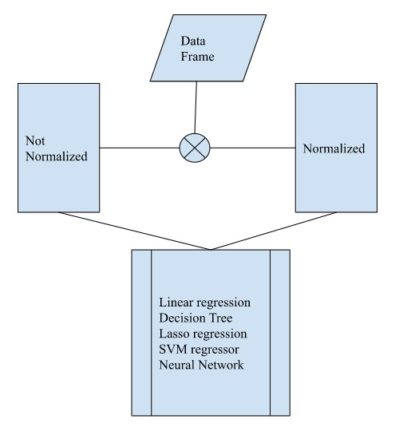

## Create X train, X test, Y train and Y test

```python
from sklearn.model_selection import train_test_split

# create X_train,X_test,y_train,y_test FROM the variables X and y, using 30% of the dataset for testing.
X_train, X_test, y_train, y_test = train_test_split(X,y, test_size = 0.3, random_state=10)

print(f'X_train: {len(X_train)} elements  |  y_train: {len(y_train)} elements')
print(f'X_test: {len(X_test)} elements    |  y_test: {len(y_test)} elements')
```

```
X_train: 190 elements  |  y_train: 190 elements
X_test: 82 elements    |  y_test: 82 elements
```

### Linear Regression

```python
#importing th necesary libraries
from sklearn.linear_model import LinearRegression

# create the linear regression model
model_regression = LinearRegression()

# train the model
model_regression.fit(X_train, y_train)

#obtain a prediction
predicted_regression = model_regression.predict(X_test)
```

```python
# checking the metrics
from sklearn.metrics import mean_squared_error, mean_absolute_error, r2_score

# call the metrics and saves them
mae = mean_absolute_error(y_test, predicted_regression)
mse = mean_squared_error(y_test, predicted_regression)
rmse = sqrt(mse)
r2 = r2_score(y_test, predicted_regression)

# creates an empty dataframe to store the results for the metrics
errors = pd.DataFrame()
errors['Metrics'] =['Mean Absolute Error MAE', 'Mean Squared Error MSE', 'Root Mean Squared Error RMSE', 'Coefficient of Determination r2']
errors['Linear_regression'] = [mae, mse, rmse, r2]
errors.set_index('Metrics', inplace = True) # sets the index
errors
```

| Metrics | Linear_regression |
| --- | --- |
| Mean Absolute Error MAE | 0.796271 |
| Mean Squared Error MSE | 1.539164 |
| Root Mean Squared Error RMSE | 1.240631 |
| Coefficient of Determination r2 | 0.999157 |

```python
# creates an empty dataframe to store the results
results = pd.DataFrame()
results['actual'] = y_test
results['predicted_regression'] = predicted_regression
results.head(5)
```

|  | actual | predicted_regression |
| --- | --- | --- |
| 180 | 148.240000 | 148.860768 |
| 24 | 43.460000 | 40.463793 |
| 183 | 129.020000 | 130.173654 |
| 214 | 117.262273 | 117.481253 |
| 56 | 61.470000 | 61.697512 |

```python
coeff = model_regression.coef_.tolist() # converts the array of coeficients to list
coefficients = pd.DataFrame() # creates an empty dataframe
coefficients['Variable'] = X.columns.tolist() # puts the names of the columns as a list and then as a rows
coefficients['Coefficient'] = coeff # creates a dataframe with the coeficients
coefficients.set_index('Variable') # sets the index
```

| Variable | Coefficient |
| --- | --- |
| Colombia_ny | 0.387995 |
| Colombia_europe | 0.458673 |
| Colombia_average | -0.722548 |
| Other_europe | 0.266651 |
| Brazil_ny | -0.178374 |
| Brazil_europe | -0.981275 |
| Brazil_average | 1.428200 |
| Robustas_ny | 0.365205 |
| Robustas_europe | 1.621685 |
| Robustas_average | -1.654103 |

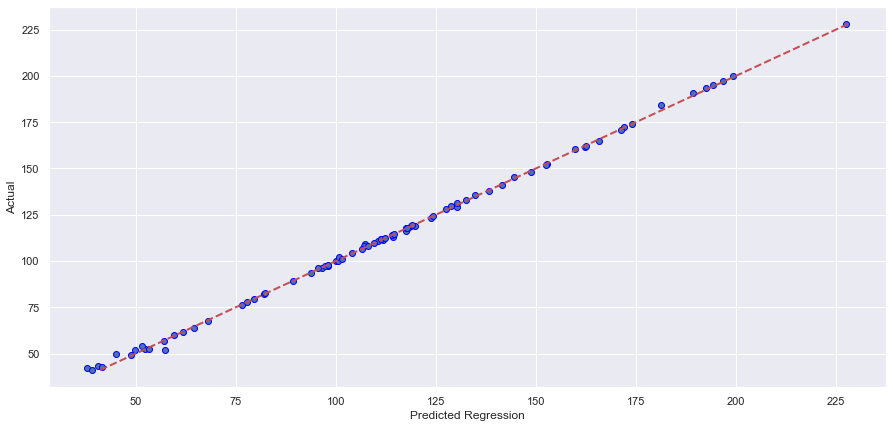

```python
# plotting Actual vs Predicted
# axes and size
fig = plt.figure(figsize = [15,7])
ax = fig.add_subplot()

# draws a scater plot wit results_predict and results
ax.scatter(results.predicted_regression, results.actual, edgecolors=(0, 0, 1))

# draws the line
ax.plot([results.actual.min(), results.actual.max()], [results.actual.min(), results.actual.max()], 'r--', lw=2)

# set label in X
ax.set_xlabel('Predicted Regression')

# set label in Y
ax.set_ylabel('Actual')

# to show the plot
plt.show()
```

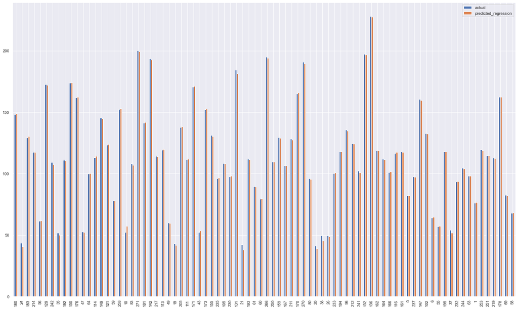

```python
# Plotting Actual price vs predicted price
results.plot(kind='bar',figsize=(25,15))
plt.show()
```

```python
#df_pred = pd.DataFrame({'actuals': y_test,'predictions': predicted_regression })
```

```python
#df_pred['error'] = np.abs(y_test - predicted_regression)
#df_pred['error'].plot(title='Distribution of Error', kind='hist')
#fig.show()
```

### Decision Tree Regressor

```python
# import the necesary libraries
from sklearn.tree import DecisionTreeRegressor

# create the model
model_tree = DecisionTreeRegressor(random_state=10)

# train the model
model_tree.fit(X_train, y_train)

# obtain the prediction
predicted_tree = model_tree.predict(X_test)
```

```python
# calls the metrics and saves them
mae = mean_absolute_error(y_test, predicted_tree)
mse = mean_squared_error(y_test, predicted_tree)
rmse = sqrt(mse)
r2 = r2_score(y_test, predicted_tree)

# dataframe to store the results for the metrics
errors['Regression_Tree'] = [mae, mse, rmse, r2]
errors
```

| Metrics | Linear_regression | Regression_Tree |
| --- | --- | --- |
| Mean Absolute Error MAE | 0.796271 | 3.144109 |
| Mean Squared Error MSE | 1.539164 | 22.463621 |
| Root Mean Squared Error RMSE | 1.240631 | 4.739580 |
| Coefficient of Determination r2 | 0.999157 | 0.987702 |

```python
# adds the results to the recently created dataframe
results['predicted_tree'] = predicted_tree
results.head(5)
```

|  | actual | predicted_regression | predicted_tree |
| --- | --- | --- | --- |
| 180 | 148.240000 | 148.860768 | 151.28 |
| 24 | 43.460000 | 40.463793 | 44.30 |
| 183 | 129.020000 | 130.173654 | 131.51 |
| 214 | 117.262273 | 117.481253 | 120.01 |
| 56 | 61.470000 | 61.697512 | 61.10 |

```python
# # creates a linear regression decision tree
# from sklearn.tree import plot_tree
# plt.figure(figsize=(20,8))#, dpi=100)
# plot_tree(model_tree, feature_names=X.columns, fontsize = 12);
```

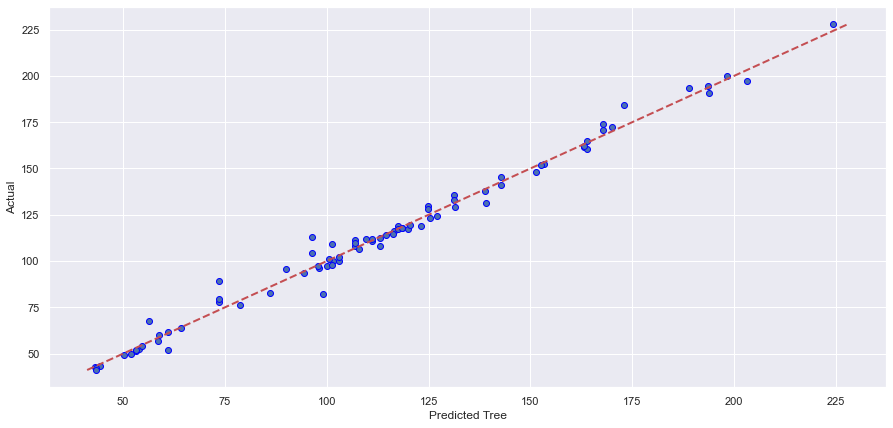

```python
# plotting Actual vs Predicted
# axes and size
fig = plt.figure(figsize = [15,7])
ax = fig.add_subplot()

# draws a scater plot wit results_predict and results
ax.scatter(results.predicted_tree, results.actual, edgecolors=(0, 0, 1))

# draws the line
ax.plot([results.actual.min(), results.actual.max()], [results.actual.min(), results.actual.max()], 'r--', lw=2)

# set label in X
ax.set_xlabel('Predicted Tree')

# set label in Y
ax.set_ylabel('Actual')

# to show the plot
plt.show()
```

### LASSO Regressor (Least Absolute Shrinkage and SelectionOperator)

```python
# import the necesary libraries
from sklearn.linear_model import Lasso

# creates the model
lasso_regressor = Lasso(fit_intercept=False)

# train the model
lasso_regressor.fit(X_train, y_train)

# obtain the predictions
predicted_lasso = lasso_regressor.predict(X_test)
```

```python
mae = mean_absolute_error(y_test, predicted_lasso)
mse = mean_squared_error(y_test, predicted_lasso)
rmse = sqrt(mse)
r2 = r2_score(y_test, predicted_lasso)

# dataframe to store the results for the metrics
errors['Regression_Lasso'] = [mae, mse, rmse, r2]
errors
```

| Metrics | Linear_regression | Regression_Tree | Regression_Lasso |
| --- | --- | --- | --- |
| Mean Absolute Error MAE | 0.796271 | 3.144109 | 1.105563 |
| Mean Squared Error MSE | 1.539164 | 22.463621 | 3.874592 |
| Root Mean Squared Error RMSE | 1.240631 | 4.739580 | 1.968398 |
| Coefficient of Determination r2 | 0.999157 | 0.987702 | 0.997879 |

```python
results['predicted_lasso'] = predicted_lasso
results.head(5)
```

|  | actual | predicted_regression | predicted_tree | predicted_lasso |
| --- | --- | --- | --- | --- |
| 180 | 148.240000 | 148.860768 | 151.28 | 148.396536 |
| 24 | 43.460000 | 40.463793 | 44.30 | 42.134627 |
| 183 | 129.020000 | 130.173654 | 131.51 | 130.018348 |
| 214 | 117.262273 | 117.481253 | 120.01 | 117.830210 |
| 56 | 61.470000 | 61.697512 | 61.10 | 60.615855 |

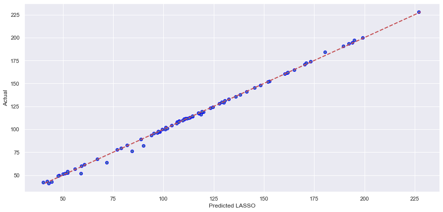

```python
# plotting Actual vs Predicted
# axes and size
fig = plt.figure(figsize = [15,7])
ax = fig.add_subplot()

# draws a scater plot wit results_predict and results
ax.scatter(results.predicted_lasso, results.actual, edgecolors=(0, 0, 1))

# draws the line
ax.plot([results.actual.min(), results.actual.max()], [results.actual.min(), results.actual.max()], 'r--', lw=2)

# set label in X
ax.set_xlabel('Predicted LASSO')

# set label in Y
ax.set_ylabel('Actual')

# to show the plot
plt.show()
```

### SVM Support Vector Machine Regressor

```python
# import the necesary libraries
from sklearn.svm import SVR

# creates the model
svm_regressor = SVR(kernel = 'rbf') # radial base function or gaussian

# train the model
svm_regressor.fit(X_train, y_train)

# obtain the predictions
svm_predicted = svm_regressor.predict(X_test)
```

```python
mae = mean_absolute_error(y_test, svm_predicted)
mse = mean_squared_error(y_test, svm_predicted)
rmse = sqrt(mse)
r2 = r2_score(y_test, svm_predicted)

# dataframe to store the results for the metrics
errors['SVM_Regression'] = [mae, mse, rmse, r2]
errors
```

| Metrics | Linear_regression | Regression_Tree | Regression_Lasso | SVM_Regression |
| --- | --- | --- | --- | --- |
| Mean Absolute Error MAE | 0.796271 | 3.144109 | 1.105563 | 12.520108 |
| Mean Squared Error MSE | 1.539164 | 22.463621 | 3.874592 | 456.083021 |
| Root Mean Squared Error RMSE | 1.240631 | 4.739580 | 1.968398 | 21.356100 |
| Coefficient of Determination r2 | 0.999157 | 0.987702 | 0.997879 | 0.750310 |

```python
results['predicted_svm'] = svm_predicted
results.head(5)
```

|  | actual | predicted_regression | predicted_tree | predicted_lasso | predicted_svm |
| --- | --- | --- | --- | --- | --- |
| 180 | 148.240000 | 148.860768 | 151.28 | 148.396536 | 141.317707 |
| 24 | 43.460000 | 40.463793 | 44.30 | 42.134627 | 74.529230 |
| 183 | 129.020000 | 130.173654 | 131.51 | 130.018348 | 128.234328 |
| 214 | 117.262273 | 117.481253 | 120.01 | 117.830210 | 118.445614 |
| 56 | 61.470000 | 61.697512 | 61.10 | 60.615855 | 73.338619 |

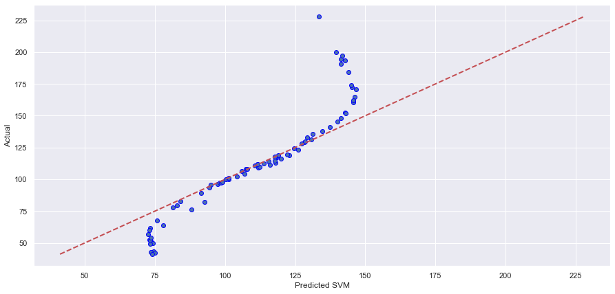

```python
# plotting Actual vs Predicted
# axes and size
fig = plt.figure(figsize = [15,7])
ax = fig.add_subplot()

# draws a scater plot wit results_predict and results
ax.scatter(results.predicted_svm, results.actual, edgecolors=(0, 0, 1))

# draws the line
ax.plot([results.actual.min(), results.actual.max()], [results.actual.min(), results.actual.max()], 'r--', lw=2)

# set label in X
ax.set_xlabel('Predicted SVM')

# set label in Y
ax.set_ylabel('Actual')

# to show the plot
plt.show()
```

Note the metrics in the SVM, the predicted values and the scatter plot, this does't make sense and needs to be normalized, as SVM are sensitive to feature scales, so is better to scale or Normalize the dataframe using Standard Scaler

## Regressions Normalized

### Methodology

In this section, the algorithms will be run Normalized using StandardScaler()

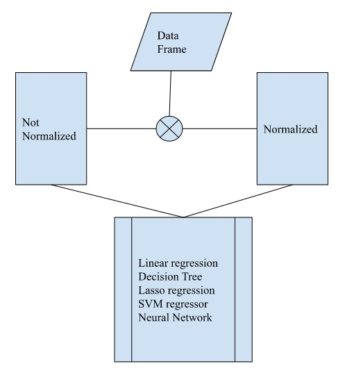

```python
# creates X and y, with All the columns for X and for y = OIC_price
X = test.iloc[:, [1,2,3,5,7,8,9,10,11,12]].values  # All the variables but OIC_price, values: to get them as numpy array
y = test.iloc[:, 0].values # OIC_price, values to get them as numpy array
```

## Normalize with StandarsScaler()

```python
# Function that applies standarization with the Standar deviation method
from sklearn.preprocessing import StandardScaler

# normalizing with standar deviation
X_scaler = StandardScaler()
y_scaler = StandardScaler()

# fits and transforms the data
X = X_scaler.fit_transform(X)
y = y.reshape(-1,1) # reshape because the array has to be a 2D array or (1 column, many rows..)
y = y_scaler.fit_transform(y)

# converting the numpy array back into dataframe
X = pd.DataFrame(X, columns = ['Colombia_ny', 'Colombia_europe', 'Colombia_average', 'Other_europe',
                               'Brazil_ny', 'Brazil_europe', 'Brazil_average', 'Robustas_ny', 'Robustas_europe',
                               'Robustas_average'])

y = np.squeeze(y) # turns the from 2 dimensions to 1 dimension
```

## Create X train, X test, Y train and Y test

```python
from sklearn.model_selection import train_test_split

# create X_train,X_test,y_train,y_test FROM the variables X and y, using 30% of the dataset for testing.
X_train, X_test, y_train, y_test = train_test_split(X, y, test_size = 0.3, random_state=10)

print(f'X_train: {len(X_train)} elements  |  y_train: {len(y_train)} elements')
print(f'X_test: {len(X_test)} elements    |  y_test: {len(y_test)} elements')
```

```
X_train: 190 elements  |  y_train: 190 elements
X_test: 82 elements    |  y_test: 82 elements
```

### Linear Regression Normalized

```python
#importing th necesary libraries
from sklearn.linear_model import LinearRegression

# create the linear regression model
model_regression = LinearRegression()

# train the model
model_regression.fit(X_train, y_train)

#obtain a prediction
predicted_regression_norm = model_regression.predict(X_test)
```

```python
# calls the metrics and saves them
mae = mean_absolute_error(y_test, predicted_regression_norm)
mse = mean_squared_error(y_test, predicted_regression_norm)
rmse = sqrt(mse)
r2 = r2_score(y_test, predicted_regression_norm)

# dataframe to store the results for the metrics
errors['Linear_Regression_Norm'] = [mae, mse, rmse, r2]
errors
```

| Metrics | Linear_regression | Regression_Tree | Regression_Lasso | SVM_Regression | Linear_Regression_Norm |
| --- | --- | --- | --- | --- | --- |
| Mean Absolute Error MAE | 0.796271 | 3.144109 | 1.105563 | 12.520108 | 0.018260 |
| Mean Squared Error MSE | 1.539164 | 22.463621 | 3.874592 | 456.083021 | 0.000809 |
| Root Mean Squared Error RMSE | 1.240631 | 4.739580 | 1.968398 | 21.356100 | 0.028450 |
| Coefficient of Determination r2 | 0.999157 | 0.987702 | 0.997879 | 0.750310 | 0.999157 |

```python
results['actual_norm'] = y_test
results['predicted_regression_norm'] = predicted_regression_norm
results.head()
```

|  | actual | predicted_regression | predicted_tree | predicted_lasso | predicted_svm | actual_norm | predicted_regression_norm |
| --- | --- | --- | --- | --- | --- | --- | --- |
| 180 | 148.240000 | 148.860768 | 151.28 | 148.396536 | 141.317707 | 0.793596 | 0.807831 |
| 24 | 43.460000 | 40.463793 | 44.30 | 42.134627 | 74.529230 | -1.609199 | -1.677907 |
| 183 | 129.020000 | 130.173654 | 131.51 | 130.018348 | 128.234328 | 0.352846 | 0.379302 |
| 214 | 117.262273 | 117.481253 | 120.01 | 117.830210 | 118.445614 | 0.083220 | 0.088242 |
| 56 | 61.470000 | 61.697512 | 61.10 | 60.615855 | 73.338619 | -1.196197 | -1.190980 |

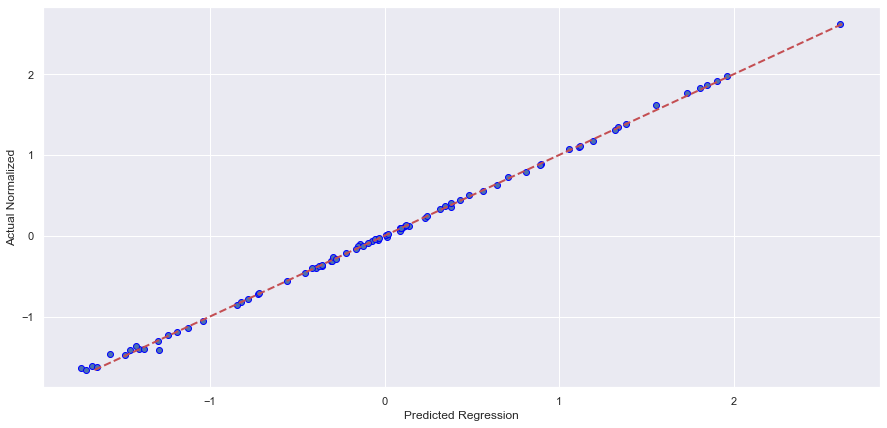

```python
# plotting Actual vs Predicted
# axes and size
fig = plt.figure(figsize = [15,7])
ax = fig.add_subplot()

# draws a scater plot wit results_predict and results
ax.scatter(results.predicted_regression_norm, results.actual_norm, edgecolors=(0, 0, 1))

# draws the line
ax.plot([results.actual_norm.min(), results.actual_norm.max()], [results.actual_norm.min(), results.actual_norm.max()], 'r--', lw=2)

# set label in X
ax.set_xlabel('Predicted Regression')

# set label in Y
ax.set_ylabel('Actual Normalized')

# to show the plot
plt.show()
```

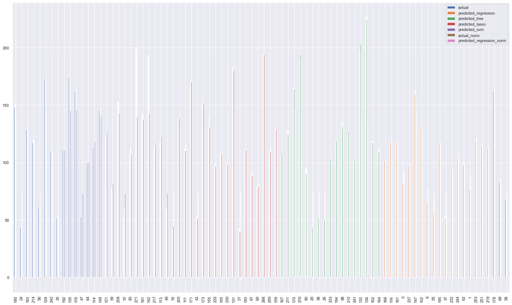

```python
# Plotting Actual price vs predicted price
results.plot(kind='bar',figsize=(25,15))
plt.show()
```

### Decision Tree Regressor Normalized

```python
# import the necesary libraries
from sklearn.tree import DecisionTreeRegressor

# create the model
model_tree = DecisionTreeRegressor(random_state=10)

# train the model
model_tree.fit(X_train, y_train)

# obtain the prediction
predicted_tree_norm = model_tree.predict(X_test)
```

```python
# calls the metrics and saves them
mae = mean_absolute_error(y_test, predicted_tree_norm)
mse = mean_squared_error(y_test, predicted_tree_norm)
rmse = sqrt(mse)
r2 = r2_score(y_test, predicted_tree_norm)

# dataframe to store the results for the metrics
errors['Regression_Tree_Norm'] = [mae, mse, rmse, r2]
errors
```

| Metrics | Linear_regression | Regression_Tree | Regression_Lasso | SVM_Regression | Linear_Regression_Norm | Regression_Tree_Norm |
| --- | --- | --- | --- | --- | --- | --- |
| Mean Absolute Error MAE | 0.796271 | 3.144109 | 1.105563 | 12.520108 | 0.018260 | 0.076258 |
| Mean Squared Error MSE | 1.539164 | 22.463621 | 3.874592 | 456.083021 | 0.000809 | 0.013131 |
| Root Mean Squared Error RMSE | 1.240631 | 4.739580 | 1.968398 | 21.356100 | 0.028450 | 0.114592 |
| Coefficient of Determination r2 | 0.999157 | 0.987702 | 0.997879 | 0.750310 | 0.999157 | 0.986329 |

```python
# adds the results to the recently created dataframe
results['predicted_tree_norm'] = predicted_tree_norm
results.head(5)
```

|  | actual | predicted_regression | predicted_tree | predicted_lasso | predicted_svm | actual_norm | predicted_regression_norm | predicted_tree_norm |
| --- | --- | --- | --- | --- | --- | --- | --- | --- |
| 180 | 148.240000 | 148.860768 | 151.28 | 148.396536 | 141.317707 | 0.793596 | 0.807831 | 0.863308 |
| 24 | 43.460000 | 40.463793 | 44.30 | 42.134627 | 74.529230 | -1.609199 | -1.677907 | -1.589936 |
| 183 | 129.020000 | 130.173654 | 131.51 | 130.018348 | 128.234328 | 0.352846 | 0.379302 | 0.409946 |
| 214 | 117.262273 | 117.481253 | 120.01 | 117.830210 | 118.445614 | 0.083220 | 0.088242 | 0.102184 |
| 56 | 61.470000 | 61.697512 | 61.10 | 60.615855 | 73.338619 | -1.196197 | -1.190980 | -1.204682 |

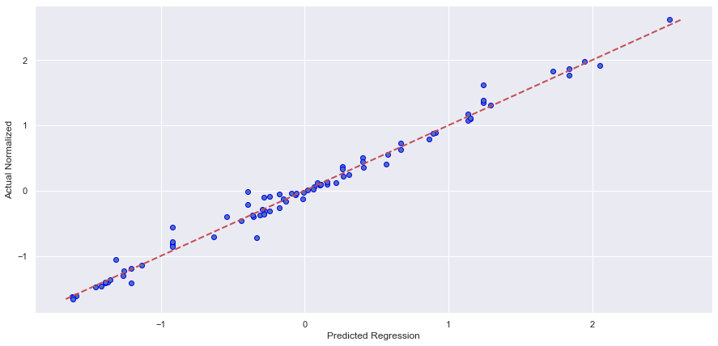

```python
# plotting Actual vs Predicted
# axes and size
fig = plt.figure(figsize = [15,7])
ax = fig.add_subplot()

# draws a scater plot wit results_predict and results
ax.scatter(results.predicted_tree_norm, results.actual_norm, edgecolors=(0, 0, 1))

# draws the line
ax.plot([results.actual_norm.min(), results.actual_norm.max()], [results.actual_norm.min(), results.actual_norm.max()], 'r--', lw=2)

# set label in X
ax.set_xlabel('Predicted Regression')

# set label in Y
ax.set_ylabel('Actual Normalized')

# to show the plot
plt.show()
```

### LASSO Regressor (Least Absolute Shrinkage and SelectionOperator)

```python
# import the necesary libraries
from sklearn.linear_model import Lasso

# creates the model
#lasso_regressor = Lasso(fit_intercept=False)
lasso_regressor = Lasso()

# train the model
lasso_regressor.fit(X_train, y_train)

# obtain the predictions
predicted_lasso_norm = lasso_regressor.predict(X_test)
```

```python
mae = mean_absolute_error(y_test, predicted_lasso_norm)
mse = mean_squared_error(y_test, predicted_lasso_norm)
rmse = sqrt(mse)
r2 = r2_score(y_test, predicted_lasso_norm)

# dataframe to store the results for the metrics
errors['Regression_Lasso'] = [mae, mse, rmse, r2]
errors
```

| Metrics | Linear_regression | Regression_Tree | Regression_Lasso | SVM_Regression | Linear_Regression_Norm | Regression_Tree_Norm |
| --- | --- | --- | --- | --- | --- | --- |
| Mean Absolute Error MAE | 0.796271 | 3.144109 | 0.747087 | 12.520108 | 0.018260 | 0.076258 |
| Mean Squared Error MSE | 1.539164 | 22.463621 | 0.943208 | 456.083021 | 0.000809 | 0.013131 |
| Root Mean Squared Error RMSE | 1.240631 | 4.739580 | 0.971189 | 21.356100 | 0.028450 | 0.114592 |
| Coefficient of Determination r2 | 0.999157 | 0.987702 | 0.018051 | 0.750310 | 0.999157 | 0.986329 |

```python
results['predicted_lasso_norm'] = predicted_lasso_norm
results.head(5)
```

|  | actual | predicted_regression | predicted_tree | predicted_lasso | predicted_svm | actual_norm | predicted_regression_norm | predicted_tree_norm | predicted_lasso_norm |
| --- | --- | --- | --- | --- | --- | --- | --- | --- | --- |
| 180 | 148.240000 | 148.860768 | 151.28 | 148.396536 | 141.317707 | 0.793596 | 0.807831 | 0.863308 | 0.013836 |
| 24 | 43.460000 | 40.463793 | 44.30 | 42.134627 | 74.529230 | -1.609199 | -1.677907 | -1.589936 | -0.008578 |
| 183 | 129.020000 | 130.173654 | 131.51 | 130.018348 | 128.234328 | 0.352846 | 0.379302 | 0.409946 | 0.008845 |
| 214 | 117.262273 | 117.481253 | 120.01 | 117.830210 | 118.445614 | 0.083220 | 0.088242 | 0.102184 | 0.006532 |
| 56 | 61.470000 | 61.697512 | 61.10 | 60.615855 | 73.338619 | -1.196197 | -1.190980 | -1.204682 | -0.003781 |

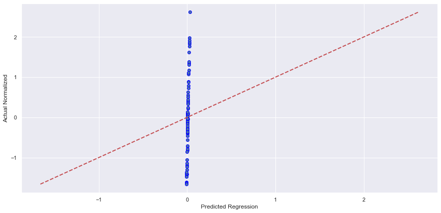

```python
# plotting Actual vs Predicted
# axes and size
fig = plt.figure(figsize = [15,7])
ax = fig.add_subplot()

# draws a scater plot wit results_predict and results
ax.scatter(results.predicted_lasso_norm, results.actual_norm, edgecolors=(0, 0, 1))

# draws the line
ax.plot([results.actual_norm.min(), results.actual_norm.max()], [results.actual_norm.min(), results.actual_norm.max()], 'r--', lw=2)

# set label in X
ax.set_xlabel('Predicted Regression')

# set label in Y
ax.set_ylabel('Actual Normalized')

# to show the plot
plt.show()
```

```python
###########  IS THIS A PROBLEM????????? ASK PROF. BABAOGLU
```

### SVM Support Vector Machine Regressor Normalized

```python
# import the necesary libraries
from sklearn.svm import SVR

# creates the model
svm_regressor = SVR(kernel = 'rbf') # radial base function or gaussian

# train the model
svm_regressor.fit(X_train, np.ravel(y_train))

# obtain the predictions
svm_predicted_norm = svm_regressor.predict(X_test)
```

```python
mae = mean_absolute_error(y_test, svm_predicted_norm)
mse = mean_squared_error(y_test, svm_predicted_norm)
rmse = sqrt(mse)
r2 = r2_score(y_test, svm_predicted_norm)

# dataframe to store the results for the metrics
errors['SVM_Regression_norm'] = [mae, mse, rmse, r2]
errors
```

| Metrics | Linear_regression | Regression_Tree | Regression_Lasso | SVM_Regression | Linear_Regression_Norm | Regression_Tree_Norm | SVM_Regression_norm |
| --- | --- | --- | --- | --- | --- | --- | --- |
| Mean Absolute Error MAE | 0.796271 | 3.144109 | 0.747087 | 12.520108 | 0.018260 | 0.076258 | 0.059528 |
| Mean Squared Error MSE | 1.539164 | 22.463621 | 0.943208 | 456.083021 | 0.000809 | 0.013131 | 0.005159 |
| Root Mean Squared Error RMSE | 1.240631 | 4.739580 | 0.971189 | 21.356100 | 0.028450 | 0.114592 | 0.071826 |
| Coefficient of Determination r2 | 0.999157 | 0.987702 | 0.018051 | 0.750310 | 0.999157 | 0.986329 | 0.994629 |

```python
results['svm_predicted_norm'] = svm_predicted_norm # predicted values when normalized
results.head(5)
```

|  | actual | predicted_regression | predicted_tree | predicted_lasso | predicted_svm | actual_norm | predicted_regression_norm | predicted_tree_norm | predicted_lasso_norm | svm_predicted_norm |
| --- | --- | --- | --- | --- | --- | --- | --- | --- | --- | --- |
| 180 | 148.240000 | 148.860768 | 151.28 | 148.396536 | 141.317707 | 0.793596 | 0.807831 | 0.863308 | 0.013836 | 0.723952 |
| 24 | 43.460000 | 40.463793 | 44.30 | 42.134627 | 74.529230 | -1.609199 | -1.677907 | -1.589936 | -0.008578 | -1.505413 |
| 183 | 129.020000 | 130.173654 | 131.51 | 130.018348 | 128.234328 | 0.352846 | 0.379302 | 0.409946 | 0.008845 | 0.305700 |
| 214 | 117.262273 | 117.481253 | 120.01 | 117.830210 | 118.445614 | 0.083220 | 0.088242 | 0.102184 | 0.006532 | 0.102109 |
| 56 | 61.470000 | 61.697512 | 61.10 | 60.615855 | 73.338619 | -1.196197 | -1.190980 | -1.204682 | -0.003781 | -1.310965 |

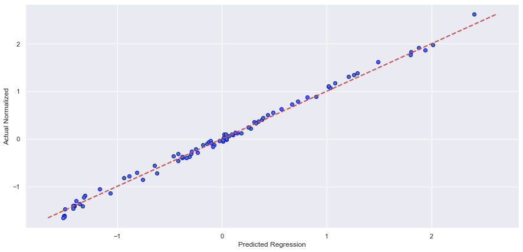

```python
# plotting Actual vs Predicted
# axes and size
fig = plt.figure(figsize = [15,7])
ax = fig.add_subplot()

# draws a scater plot wit results_predict and results
ax.scatter(results.svm_predicted_norm, results.actual_norm, edgecolors=(0, 0, 1))

# draws the line
ax.plot([results.actual_norm.min(), results.actual_norm.max()], [results.actual_norm.min(), results.actual_norm.max()], 'r--', lw=2)

# set label in X
ax.set_xlabel('Predicted Regression')

# set label in Y
ax.set_ylabel('Actual Normalized')

# to show the plot
plt.show()
```

```python
errors_transposed = errors.T
errors_transposed
```

| Metrics | Mean Absolute Error MAE | Mean Squared Error MSE | Root Mean Squared Error RMSE | Coefficient of Determination r2 |
| --- | --- | --- | --- | --- |
| Linear_regression | 0.796271 | 1.539164 | 1.240631 | 0.999157 |
| Regression_Tree | 3.144109 | 22.463621 | 4.739580 | 0.987702 |
| Regression_Lasso | 0.747087 | 0.943208 | 0.971189 | 0.018051 |
| SVM_Regression | 12.520108 | 456.083021 | 21.356100 | 0.750310 |
| Linear_Regression_Norm | 0.018260 | 0.000809 | 0.028450 | 0.999157 |
| Regression_Tree_Norm | 0.076258 | 0.013131 | 0.114592 | 0.986329 |
| SVM_Regression_norm | 0.059528 | 0.005159 | 0.071826 | 0.994629 |

```python
from sklearn.preprocessing import minmax_scale
errors_transposed[:] = minmax_scale(errors_transposed)
errors_transposed
```

| Metrics | Mean Absolute Error MAE | Mean Squared Error MSE | Root Mean Squared Error RMSE | Coefficient of Determination r2 |
| --- | --- | --- | --- | --- |
| Linear_regression | 0.062232 | 0.003373 | 0.056836 | 1.000000 |
| Regression_Tree | 0.250031 | 0.049252 | 0.220893 | 0.988324 |
| Regression_Lasso | 0.058298 | 0.002066 | 0.044203 | 0.000000 |
| SVM_Regression | 1.000000 | 1.000000 | 1.000000 | 0.746360 |
| Linear_Regression_Norm | 0.000000 | 0.000000 | 0.000000 | 1.000000 |
| Regression_Tree_Norm | 0.004639 | 0.000027 | 0.004039 | 0.986925 |
| SVM_Regression_norm | 0.003301 | 0.000010 | 0.002034 | 0.995385 |